# Filtering Deletions

> Use `Rscript -e 'library(knitr); knit2html("newDELfilter.Rmd", quiet=T)'` to compile this on the EMBL server.

First, in order to access information easier, let's reformat the VCF on the command line:

```bash
svprops ../../../data/variants/SVs/PE.delly072.DEL.vcf.gz > PE.delly072.DEL.info
zcat ../../../data/variants/SVs/PE.delly072.DEL.vcf.gz \
    | awk -f ../vcfinfo.awk -W source '\
    BEGIN{OFS="\t"; print "id","mapq", "pass"}
    !/^#/ { print $3, INFO["MAPQ"], $7}' \
    > PE.delly072.DEL.moreinfo
less ../../../data/dm6_annotation/mappability/dm6_split_100.smooth201.bedGraph.gz \
    | awk '$4==0' > uniqueAreas.bed
```

Reading all information into R

```r
x = read.table("PE.delly072.DEL.info", header=T, stringsAsFactors = F)
y = read.table(gzfile("../../../data/variants/SVs/PE.delly072.DEL.vcf.gz"), stringsAsFactors = F)
z = read.table("PE.delly072.DEL.moreinfo", header=T, stringsAsFactors = F)
```

Data gets reformatted in the background.

> Imprecise: **3851**, precise: **6570**

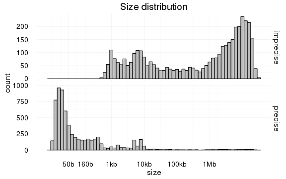

## Filter by Delly's filter *PASS*

```r
d = subset(d, pass == "PASS")
```

> Imprecise: **645**, precise: **6110**

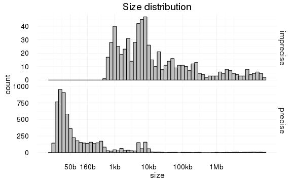

## Filter by MAPQ >= 60

```r
d = subset(d, mapq >= 60)
```

> Imprecise: **253**, precise: **5595**

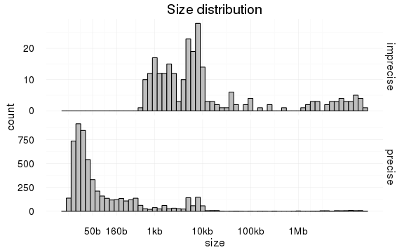

## Filter by combined genotypes

```
##
## ./.../. 0/0../. 0/0.0/0 0/0.0/1 0/1../. 0/1.0/0 0/1.0/1 0/1.1/1 1/1../.
##      34       1     280       3       4    1972     195    1584      13
## 1/1.0/0 1/1.0/1 1/1.1/1
##       2      12    1748
```

```r
d = subset(d, combinedGT %in% c("0/1.0/0", "0/1.1/1", "1/1.1/1"))
```

> Imprecise: **104**, precise: **5200**

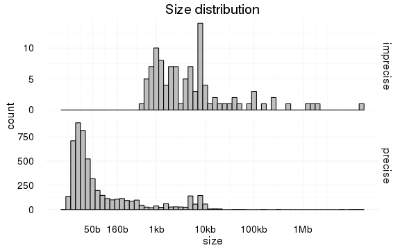

## Filter by chromosomes

We are only interested in certain chromosomes

```
##
##                          0/1.0/0 0/1.1/1 1/1.1/1
##   chr2L                      762     686     694
##   chr2R                      860     588     656
##   chr3L                      866     792     776
##   chr3R                     1168     812     610
##   chr4                         2       2      46
##   chrUn_CP007081v1             0       2       4
##   chrUn_DS483562v1             0       0       4
##   chrUn_DS483824v1             2       0       0
##   chrX                       284     286     702
##   chrX_DS484963v1_random       0       0       2
##   chrY                         0       0       2
```

```r
d = subset(d, chr %in% c("chr2L","chr2R","chr3L","chr3R","chrX"))
```

> Imprecise: **103**, precise: **5168**

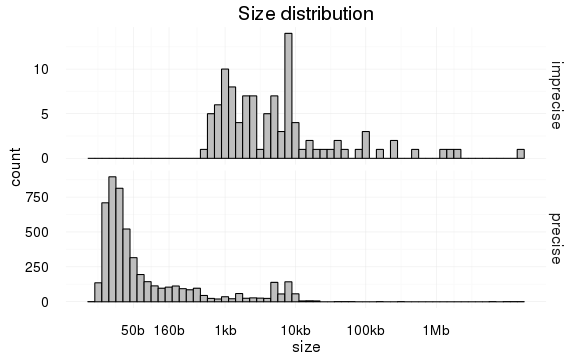

## Filter by read support

First I would argue that an extremely high ref or alt support means there is something wrong, so I remove them:

```r
bad_ids = unique( subset(d, (precise == "precise" & (RR >= 500 | RV >= 500) )
                          | (precise == "imprecise" & (DR >= 750 | DV >= 750) ))$id )
d = subset(d, !(id %in% bad_ids))
```

Then I will require a **minimum support**. For precise calls, require at least 25 total reads in the cross and 15 total reads in the virginizer. For imprecise, let's say 40 and 20. This cutoff is shown as a **dashed orange line** in the plots below.

```r
lines = data.frame(intercept = c(25,      40,      15,    20),
                   sample    = c("cross", "cross", "vrg", "vrg"),
                   precise   = c("precise","imprecise","precise","imprecise"),
                   slope = rep(-1,4),
                   stringsAsFactors = F)
```

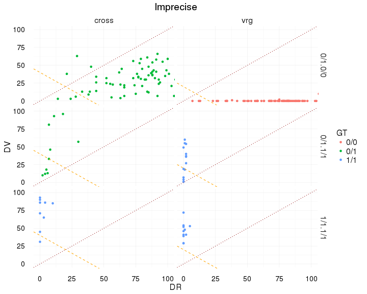

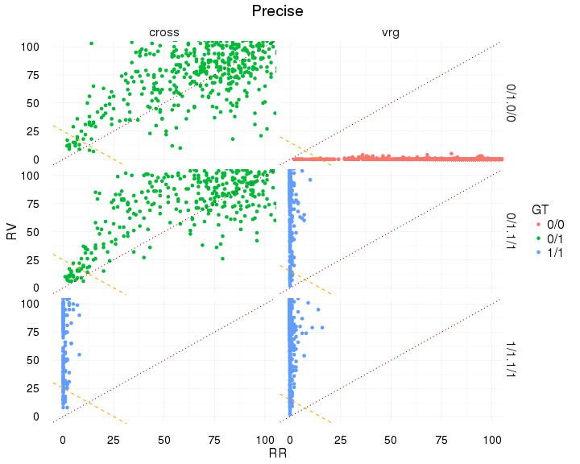

```r
ids = intersect( subset(d, precise=="precise"   & sample=="cross" & RR+RV >= 25 |
                           precise=="imprecise" & sample=="cross" & DV+DR >= 40 )$id,
                 subset(d, precise=="precise"   & sample=="vrg"   & RR+RV >= 15 |
                           precise=="imprecise" & sample=="vrg"   & DV+DR >= 20  )$id)
d = subset(d, id %in% ids)
```

> Imprecise: **93**, precise: **5044**

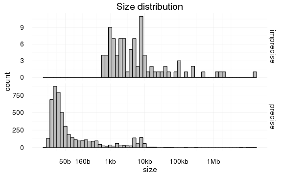

## Filter by read depth ratio

Read depth can only be assessed for deletions of a minimum size. Let's choose **160bp** for now.

```r
d$big = factor(d$size >= 160, levels=c(F,T), labels=c("small","big"))
```

```
##
##         imprecise precise
##   small         0    3878
##   big          93    1166
```

Let's have a look at the ratio of read counts within the interval to the read counts in left and right flanking intervals, i.e. `RC/(RCL+RCR)`. Note that I zoom in to a range of 0-3 here.

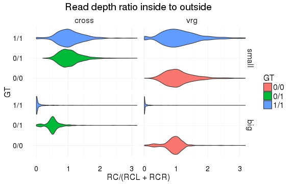

### Filtering by read depth signal

It looks like for “large” deletions the signal is actually useful. We can apply a filter to that. Let's take the 10% - 90% quantiles for example:

```r
RClim = subset(d,big=="big") %>%
        group_by(GT, sample) %>%
        summarise(y = median(RC/(RCL+RCR)),
                  ymax = quantile(RC/(RCL+RCR), 0.9),
                  ymin = quantile(RC/(RCL+RCR), 0.1) )
```

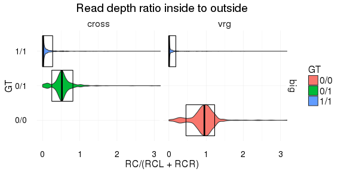

Of course in some regions we want to correct that, e.g. a minimum of 0 for the 1/1 cases. Here are the values that I propose:

| GT | sample | y | ymax | ymin |
| --- | --- | --- | --- | --- |
| 0/0 | vrg | 0.9526213 | 1.5000000 | 0.5000000 |
| 0/1 | cross | 0.5205367 | 0.8151719 | 0.2477517 |
| 1/1 | cross | 0.0160954 | 0.4000000 | 0.0000000 |
| 1/1 | vrg | 0.0040010 | 0.4000000 | 0.0000000 |

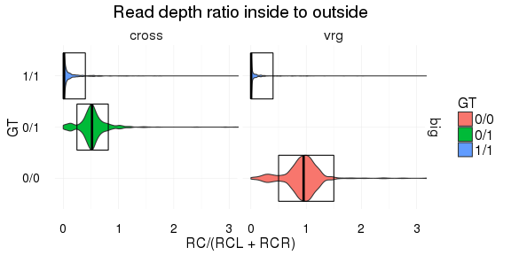

Note that I **do not** apply the criterium now. Instead we'll filter differently in the next step.

### Filter by read depth ratio *between samples*

The only way read depth filters make sense is in a **comparison between samples** because the read depth signal is highly influenced by mappability and random fluctuations in coverage.

```r
d$RC_ratio = d$RC / (d$RCL + d$RCR)
RDratios = dcast(subset(d, big=="big"), id + size + combinedGT + precise ~ sample, value.var="RC_ratio")
```

Let's first look at the genotypes 0/1 0/0. Here we would expect inside-to-outside read depth ratios of 50% in the cross and 100% in the virginizer. But since this is not relevant due to mappability issues, we'll only look at the difference of these ratios and require a minimum difference, i.e. that \(r_{vrg} \geq r_{cross} + 0.2\).

Actually, we expect random fluctuations on intervals to decrease with interval size. This is why a **size-dependent** or *dynamic* cut-off makes much more sense.

> I want to investigate this dependncy more in the future. This might be a useful filter for Delly

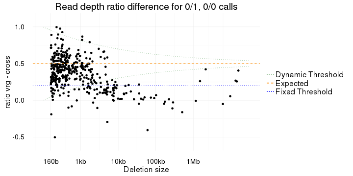

Next, for genotype 0/1 1/1 we would expect ratios of 50% and 0%, respectively, so looking at the difference, we again require a minimum distance, i.e \(r_{vrg} \leq r_{cross} -0.2\). Also here we will use the dynamic cut-off.

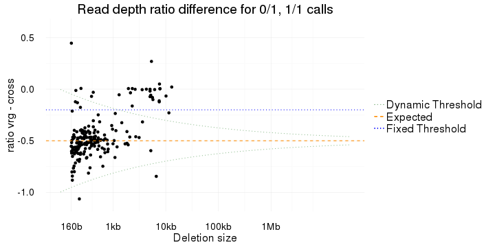

### Apply dynamic read depth filter

I manually inspected the calls above 2 kb that get kicked out by the read depth ratio filter and it looks very convincing. As a side note, we are going to put the **common deletions into a separate file** as they don't allow a comparison between samples.

```r
good_IDs1 = subset(RDratios,  # Fixed Threshold
      combinedGT=="0/1.0/0" & cross < vrg -0.2 |
      combinedGT=="0/1.1/1" & vrg < cross -0.2)$id
RDratios$dynThr = dynThrF(RDratios$size) # Arbitrary function that shrinks in a nice shape
good_IDs2 = subset(RDratios, # Dynamic Threshold
      combinedGT=="0/1.0/0" & vrg-cross < dynThr+0.5 & vrg-cross > 0.5-dynThr |
      combinedGT=="0/1.1/1" & vrg-cross < dynThr-0.5 & vrg-cross > -0.5 -dynThr)$id
d = subset(d, big=="small" | combinedGT == "1/1.1/1" | id %in% good_IDs2)
```

> Imprecise: **38**, precise: **4959**

```
##
##         imprecise precise
##   small         0    3878
##   big          38    1081
```

## Stratify by mappability

```r
# find overlaps between deletions and unique regions
uniq = reads <- import.bed("uniqueAreas.bed")#, genome="dm6")
dels = makeGRangesFromDataFrame(subset(d, sample=="cross", select=c("chr","start","end","id")),
                                ignore.strand=T, keep.extra.columns=T)
seqlevels(dels) = seqlevels(uniq)
hits = findOverlaps(uniq, dels)
hits = pintersect(dels[subjectHits(hits)], uniq[queryHits(hits)])

# Select deletions covered to 50% by unique regions
highConf = data.frame(id = hits$id, size = end(hits) - start(hits)+1) %>%
  group_by(id) %>%
  dplyr::summarize(total_size = sum(size), intervals = length(size)) %>%
  inner_join(subset(d, sample=="cross", select=c(id,size)), by="id") %>%
  filter(total_size >= 0.5*size)
d$confidence = factor(d$id %in% highConf$id, levels=c(T,F), labels=c("high","low"))
```

```
##
##        imprecise precise
##   high        16    4244
##   low         22     715
```

```
##
##        small  big
##   high  3809  451
##   low     69  668
```

```
##
##        0/1.0/0 0/1.1/1 1/1.1/1
##   high    1728    1488    1044
##   low       96      30     611
```

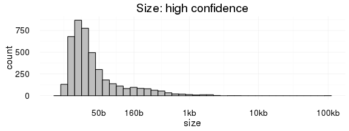

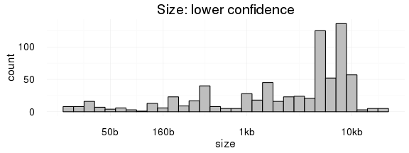

## Summary

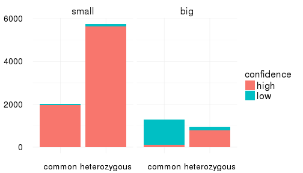

```
##
##         common heterozygous
##   chr2L    670         1386
##   chr2R    628         1360
##   chr3L    750         1552
##   chr3R    588         1894
##   chrX     674          492
```

## Write to files

We will create 4 different sets from this, in order to validate them seperately:

1. common + heterozygous, high confidence calls \(< 50bp\). We cannot validate those by PCR
2. common + heterozygous, high confidence calls \(\geq 50bp\) and \(< 160bp\). Those will be validated by PCR
3. heterozygous, high confidence calls \(\geq 160bp\). We drop common calls as they were not read-depth selected
4. heterozygous, low confidence calls \(\geq 160bp\).

| Var1 | Freq |
| --- | --- |
| 50_160.highConf | 737 |
| above160.highConf | 395 |
| above160.lowConf | 75 |
| below50.highConf | 3072 |
| discard | 718 |

```r
for (x in unique(d$finalSet)) {
  #if (x == "discard") next
  write.table(unique(subset(d, finalSet == x)$id),
              file=paste("DEL.",x,".ids.txt",sep=""),
              quote=F, row.names=F, col.names=F)
}
```

```bash
VCF=../../../data/variants/SVs/PE.delly072.DEL.vcf.gz
for x in DEL.*.ids.txt;
  do
  less $VCF | grep '^#' > ${x%.ids.txt}.vcf
  less $VCF | grep -f $x >> ${x%.ids.txt}.vcf
  done
rm DEL.*.ids.txt PE.delly072.DEL.info PE.delly072.DEL.moreinfo uniqueAreas.bed
```

## Appendix: Custom plots for other purposes

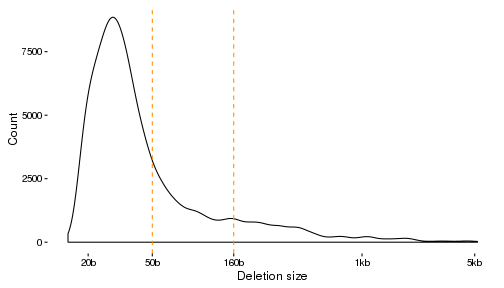

```r
p1 = ggplot(subset(d,sample=="cross" & finalSet != "discard")) + aes(x=size, y=..count..) + geom_density() + scale_x_log10(breaks=c(20,50,160,1000,5000,10000,100000), labels=c("20b","50b","160b","1kb","5kb","10kb","100kb")) + theme_classic() + xlab("Deletion size") + ylab("Count") + geom_vline(xintercept=c(50,160), col="darkorange", linetype="dashed")
p1
```

```r
ggsave("DEL.size.density.pdf", p1, width=5, height=3)
```

```r
#p2 = ggplot(subset(d,sample=="cross")) + aes(x="DEL",y=size) + geom_violin(scale="width", fill="black") + scale_y_log10(breaks=c(10,100,1000,10000,100000,1000000), labels=c("10b","100b","1kb","10kb","100kb","1Mb")) + theme_classic() + xlab("Deletion size") + ylab("Count") + coord_flip()
#p2
#ggsave("plots/del.size.violin.pdf", p2, width=5, height=3)
```